# Home Credit Default Risk (HCDR)

## Installments Payments Dataset

### Summary

```python
insDF = datasets["installments_payments"]
```

**Column information from Data Dictionary**

- **SK_ID_PREV** ID of previous credit in Home credit related to loan in our sample. (One loan in our sample can have 0,1,2 or more previous loans in Home Credit)
- **SK_ID_CURR** ID of loan in our sample
- **NUM_INSTALMENT_VERSION** Version of installment calendar (0 is for credit card) of previous credit. Change of installment version from month to month signifies that some parameter of payment calendar has changed
- **NUM_INSTALMENT_NUMBER** On which installment we observe payment
- **DAYS_INSTALMENT** When the installment of previous credit was supposed to be paid (relative to application date of current loan)
- **DAYS_ENTRY_PAYMENT** When was the installments of previous credit paid actually (relative to application date of current loan)
- **AMT_INSTALMENT** What was the prescribed installment amount of previous credit on this installment
- **AMT_PAYMENT** What the client actually paid on previous credit on this installment

```python
insDF.info()
```

```
<class 'pandas.core.frame.DataFrame'>
RangeIndex: 13605401 entries, 0 to 13605400
Data columns (total 8 columns):
 #   Column                  Dtype
---  ------                  -----
 0   SK_ID_PREV              int32
 1   SK_ID_CURR              int32
 2   NUM_INSTALMENT_VERSION  float16
 3   NUM_INSTALMENT_NUMBER   int16
 4   DAYS_INSTALMENT         float16
 5   DAYS_ENTRY_PAYMENT      float16
 6   AMT_INSTALMENT          float32
 7   AMT_PAYMENT             float32
dtypes: float16(3), float32(2), int16(1), int32(2)
memory usage: 311.4 MB
```

```python
insDF.isna().sum()
```

```
SK_ID_PREV                   0
SK_ID_CURR                   0
NUM_INSTALMENT_VERSION       0
NUM_INSTALMENT_NUMBER        0
DAYS_INSTALMENT              0
DAYS_ENTRY_PAYMENT        2905
AMT_INSTALMENT               0
AMT_PAYMENT               2905
dtype: int64
```

```python
# Convert days to positive values
day_convert(insDF)
insDF.head()
```

|  | SK_ID_PREV | SK_ID_CURR | NUM_INSTALMENT_VERSION | NUM_INSTALMENT_NUMBER | DAYS_INSTALMENT | DAYS_ENTRY_PAYMENT | AMT_INSTALMENT | AMT_PAYMENT |
| --- | --- | --- | --- | --- | --- | --- | --- | --- |
| 0 | 1054186 | 161674 | 1.0 | 6 | 1180.0 | 1187.0 | 6948.359863 | 6948.359863 |
| 1 | 1330831 | 151639 | 0.0 | 34 | 2156.0 | 2156.0 | 1716.525024 | 1716.525024 |
| 2 | 2085231 | 193053 | 2.0 | 1 | 63.0 | 63.0 | 25425.000000 | 25425.000000 |
| 3 | 2452527 | 199697 | 1.0 | 3 | 2418.0 | 2426.0 | 24350.130859 | 24350.130859 |
| 4 | 2714724 | 167756 | 1.0 | 2 | 1383.0 | 1366.0 | 2165.040039 | 2160.584961 |

```python
insDF['PAYMENT_DELAY']=insDF['DAYS_ENTRY_PAYMENT']-insDF['DAYS_INSTALMENT']
insDF['INSTALLMENT_DIFFERENCE']=insDF['AMT_PAYMENT']-insDF['AMT_INSTALMENT']
insDF['LATE_PAYMENT']=[0 if x <= 0 else 1 for x in insDF['PAYMENT_DELAY']]
insDF['EXTRA_PAYMENT']=[0 if x <= 0 else 1 for x in insDF['INSTALLMENT_DIFFERENCE']]
```

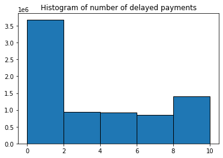

```python
bins= [0,2,4,6,8,10]
plt.hist(insDF['PAYMENT_DELAY'], bins=bins, edgecolor="k")
plt.xticks(bins)
plt.title('Histogram of number of delayed payments')
plt.show()
```

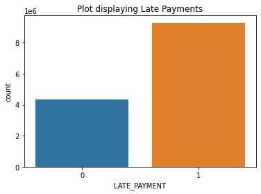

```python
ax = sns.countplot(x="LATE_PAYMENT", data=insDF).set(title="Plot displaying Late Payments")
```

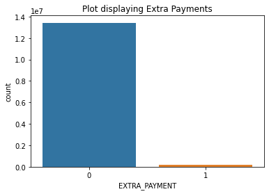

```python
ax = sns.countplot(x="EXTRA_PAYMENT", data=insDF).set(title="Plot displaying Extra Payments")
```

```python
# Check the data for 1 Current ID in the first million rows
insDF[0:1000000][(insDF["SK_ID_CURR"]==199697)]
```

|  | SK_ID_PREV | SK_ID_CURR | NUM_INSTALMENT_VERSION | NUM_INSTALMENT_NUMBER | DAYS_INSTALMENT | DAYS_ENTRY_PAYMENT | AMT_INSTALMENT | AMT_PAYMENT | PAYMENT_DELAY | INSTALLMENT_DIFFERENCE | LATE_PAYMENT | EXTRA_PAYMENT |
| --- | --- | --- | --- | --- | --- | --- | --- | --- | --- | --- | --- | --- |
| 3 | 2452527 | 199697 | 1.0 | 3 | 2418.0 | 2426.0 | 24350.130859 | 24350.130859 | 8.0 | 0.000000 | 1 | 0 |
| 310435 | 2361855 | 199697 | 1.0 | 2 | 874.0 | 864.0 | 21179.699219 | 21164.400391 | -10.0 | -15.298828 | 0 | 0 |
| 381670 | 2361855 | 199697 | 1.0 | 9 | 664.0 | 663.0 | 21179.699219 | 21179.699219 | -1.0 | 0.000000 | 0 | 0 |
| 806132 | 2361855 | 199697 | 1.0 | 7 | 724.0 | 707.0 | 21179.699219 | 21128.400391 | -17.0 | -51.298828 | 0 | 0 |
| 853630 | 2361855 | 199697 | 1.0 | 2 | 874.0 | 894.0 | 21179.699219 | 15.300000 | 20.0 | -21164.398438 | 1 | 0 |
| 860430 | 2361855 | 199697 | 1.0 | 6 | 754.0 | 739.0 | 21179.699219 | 21143.699219 | -15.0 | -36.000000 | 0 | 0 |
| 949157 | 2452527 | 199697 | 1.0 | 5 | 2358.0 | 2368.0 | 24350.130859 | 24350.130859 | 10.0 | 0.000000 | 1 | 0 |
| 985427 | 2361855 | 199697 | 1.0 | 3 | 844.0 | 842.0 | 21179.699219 | 20969.099609 | -2.0 | -210.599609 | 0 | 0 |

```python
instal = insDF.groupby(['SK_ID_CURR']).agg(['nunique','mean', 'count', 'std', 'sum', 'min', 'max'])
instal.columns = [ '_'.join(str(i) for i in col) for col in instal.columns]
instal.reset_index(inplace=True)
```

```python
# Create a new feature - Number of missed installments -> Max Install number - total intallment count
instal['INSTALLMENTS_MISSED']=instal['NUM_INSTALMENT_NUMBER_max'] - instal['NUM_INSTALMENT_NUMBER_count']
```

```python
instal.head()
```

|  | SK_ID_CURR | SK_ID_PREV_nunique | SK_ID_PREV_mean | SK_ID_PREV_count | SK_ID_PREV_std | SK_ID_PREV_sum | SK_ID_PREV_min | SK_ID_PREV_max | NUM_INSTALMENT_VERSION_nunique | NUM_INSTALMENT_VERSION_mean | NUM_INSTALMENT_VERSION_count | NUM_INSTALMENT_VERSION_std | NUM_INSTALMENT_VERSION_sum | NUM_INSTALMENT_VERSION_min | NUM_INSTALMENT_VERSION_max | NUM_INSTALMENT_NUMBER_nunique | NUM_INSTALMENT_NUMBER_mean | NUM_INSTALMENT_NUMBER_count | NUM_INSTALMENT_NUMBER_std | NUM_INSTALMENT_NUMBER_sum | NUM_INSTALMENT_NUMBER_min | NUM_INSTALMENT_NUMBER_max | DAYS_INSTALMENT_nunique | DAYS_INSTALMENT_mean | DAYS_INSTALMENT_count | DAYS_INSTALMENT_std | DAYS_INSTALMENT_sum | DAYS_INSTALMENT_min | DAYS_INSTALMENT_max | … |
| --- | --- | --- | --- | --- | --- | --- | --- | --- | --- | --- | --- | --- | --- | --- | --- | --- | --- | --- | --- | --- | --- | --- | --- | --- | --- | --- | --- | --- | --- | --- |
| 0 | 100001 | 2 | 1.576389e+06 | 7 | 257795.383246 | 11034724 | 1369693 | 1851984 | 2 | 1.142578 | 7 | 0.377930 | 8.0 | 1.0 | 2.0 | 4 | 2.714286 | 7 | 1.112697 | 19.0 | 1 | 4 | 7 | 2188.0 | 7 | inf | 15312.0 | 1619.0 | 2916.0 | … |
| 1 | 100002 | 1 | 1.038818e+06 | 19 | 0.000000 | 19737542 | 1038818 | 1038818 | 2 | 1.052734 | 19 | 0.229492 | 20.0 | 1.0 | 2.0 | 19 | 10.000000 | 19 | 5.627314 | 190.0 | 1 | 19 | 19 | 295.0 | 19 | 168.7500 | 5604.0 | 25.0 | 565.0 | … |
| 2 | 100003 | 3 | 2.290070e+06 | 25 | 320488.923470 | 57251754 | 1810518 | 2636178 | 2 | 1.040039 | 25 | 0.200073 | 26.0 | 1.0 | 2.0 | 12 | 5.080000 | 25 | 3.134751 | 127.0 | 1 | 12 | 25 | 1378.0 | 25 | inf | 34464.0 | 536.0 | 2310.0 | … |
| 3 | 100004 | 1 | 1.564014e+06 | 3 | 0.000000 | 4692042 | 1564014 | 1564014 | 2 | 1.333008 | 3 | 0.577148 | 4.0 | 1.0 | 2.0 | 3 | 2.000000 | 3 | 1.000000 | 6.0 | 1 | 3 | 3 | 754.0 | 3 | 30.0000 | 2262.0 | 724.0 | 784.0 | … |
| 4 | 100005 | 1 | 2.495675e+06 | 9 | 0.000000 | 22461075 | 2495675 | 2495675 | 2 | 1.111328 | 9 | 0.333252 | 10.0 | 1.0 | 2.0 | 9 | 5.000000 | 9 | 2.738613 | 45.0 | 1 | 9 | 9 | 586.0 | 9 | 82.1875 | 5272.0 | 466.0 | 706.0 | … |

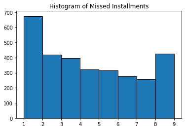

```python
bins= [1,2,3,4,5,6,7,8,9]
plt.hist(instal['INSTALLMENTS_MISSED'], bins=bins, edgecolor="k")
plt.xticks(bins)
plt.title('Histogram of Missed Installments')
plt.show()
```

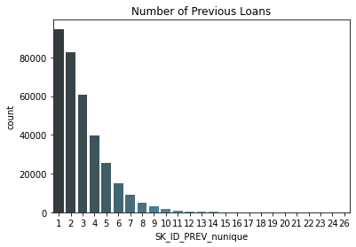

```python
ax = sns.countplot(x="SK_ID_PREV_nunique", data=instal, palette="GnBu_d").set(title="Number of Previous Loans")
```

### Target Corelation

```python
instalTrain = instal.set_index('SK_ID_CURR').join(other1.set_index('SK_ID_CURR'))
```

```python
correlations = instalTrain.corr()['TARGET'].sort_values()
print('Most Positive Correlations:\n', correlations.tail(10))
print('\nMost Negative Correlations:\n', correlations.head(10))
```

```
Most Positive Correlations:
 NUM_INSTALMENT_NUMBER_max         0.006304
AMT_INSTALMENT_nunique            0.009646
PAYMENT_DELAY_std                 0.009860
SK_ID_PREV_min                    0.017409
AMT_PAYMENT_nunique               0.024185
INSTALLMENT_DIFFERENCE_nunique    0.026795
LATE_PAYMENT_nunique              0.036174
INSTALLMENTS_MISSED               0.041861
LATE_PAYMENT_std                  0.053619
TARGET                            1.000000
Name: TARGET, dtype: float64

Most Negative Correlations:
 DAYS_ENTRY_PAYMENT_max    -0.058795
DAYS_INSTALMENT_max       -0.058647
LATE_PAYMENT_mean         -0.051083
DAYS_ENTRY_PAYMENT_mean   -0.043991
DAYS_INSTALMENT_mean      -0.043508
DAYS_ENTRY_PAYMENT_sum    -0.038162
DAYS_INSTALMENT_sum       -0.037784
LATE_PAYMENT_min          -0.036547
LATE_PAYMENT_sum          -0.035991
SK_ID_PREV_nunique        -0.032745
Name: TARGET, dtype: float64
```

# Feature Engineering

```python
for ds_name in ds_names:
    del datasets[ds_name]
    datasets[ds_name] = load_data(os.path.join(DATA_DIR, f'{ds_name}.csv'), ds_name)
```

```
Memory usage of dataframe is 286.23 MB
Memory usage after optimization is: 92.38 MB
Decreased by 67.7%


application_train: shape is (307511, 122)
```

|  | SK_ID_CURR | TARGET | NAME_CONTRACT_TYPE | CODE_GENDER | FLAG_OWN_CAR | FLAG_OWN_REALTY | CNT_CHILDREN | AMT_INCOME_TOTAL | AMT_CREDIT | AMT_ANNUITY | AMT_GOODS_PRICE | NAME_TYPE_SUITE | NAME_INCOME_TYPE | NAME_EDUCATION_TYPE | NAME_FAMILY_STATUS | NAME_HOUSING_TYPE | REGION_POPULATION_RELATIVE | DAYS_BIRTH | DAYS_EMPLOYED | DAYS_REGISTRATION | DAYS_ID_PUBLISH | OWN_CAR_AGE | FLAG_MOBIL | FLAG_EMP_PHONE | FLAG_WORK_PHONE | FLAG_CONT_MOBILE | FLAG_PHONE | FLAG_EMAIL | OCCUPATION_TYPE | … |
| --- | --- | --- | --- | --- | --- | --- | --- | --- | --- | --- | --- | --- | --- | --- | --- | --- | --- | --- | --- | --- | --- | --- | --- | --- | --- | --- | --- | --- | --- | --- |
| 0 | 100002 | 1 | Cash loans | M | N | Y | 0 | 202500.0 | 406597.5 | 24700.5 | 351000.0 | Unaccompanied | Working | Secondary / secondary special | Single / not married | House / apartment | 0.018799 | -9461 | -637 | -3648.0 | -2120 | NaN | 1 | 1 | 0 | 1 | 1 | 0 | Laborers | … |
| 1 | 100003 | 0 | Cash loans | F | N | N | 0 | 270000.0 | 1293502.5 | 35698.5 | 1129500.0 | Family | State servant | Higher education | Married | House / apartment | 0.003542 | -16765 | -1188 | -1186.0 | -291 | NaN | 1 | 1 | 0 | 1 | 1 | 0 | Core staff | … |
| 2 | 100004 | 0 | Revolving loans | M | Y | Y | 0 | 67500.0 | 135000.0 | 6750.0 | 135000.0 | Unaccompanied | Working | Secondary / secondary special | Single / not married | House / apartment | 0.010033 | -19046 | -225 | -4260.0 | -2531 | 26.0 | 1 | 1 | 1 | 1 | 1 | 0 | Laborers | … |
| 3 | 100006 | 0 | Cash loans | F | N | Y | 0 | 135000.0 | 312682.5 | 29686.5 | 297000.0 | Unaccompanied | Working | Secondary / secondary special | Civil marriage | House / apartment | 0.008018 | -19005 | -3039 | -9832.0 | -2437 | NaN | 1 | 1 | 0 | 1 | 0 | 0 | Laborers | … |
| 4 | 100007 | 0 | Cash loans | M | N | Y | 0 | 121500.0 | 513000.0 | 21865.5 | 513000.0 | Unaccompanied | Working | Secondary / secondary special | Single / not married | House / apartment | 0.028656 | -19932 | -3038 | -4312.0 | -3458 | NaN | 1 | 1 | 0 | 1 | 0 | 0 | Core staff | … |

```
Memory usage of dataframe is 45.00 MB
Memory usage after optimization is: 14.60 MB
Decreased by 67.6%


application_test: shape is (48744, 121)
```

|  | SK_ID_CURR | NAME_CONTRACT_TYPE | CODE_GENDER | FLAG_OWN_CAR | FLAG_OWN_REALTY | CNT_CHILDREN | AMT_INCOME_TOTAL | AMT_CREDIT | AMT_ANNUITY | AMT_GOODS_PRICE | NAME_TYPE_SUITE | NAME_INCOME_TYPE | NAME_EDUCATION_TYPE | NAME_FAMILY_STATUS | NAME_HOUSING_TYPE | REGION_POPULATION_RELATIVE | DAYS_BIRTH | DAYS_EMPLOYED | DAYS_REGISTRATION | DAYS_ID_PUBLISH | OWN_CAR_AGE | FLAG_MOBIL | FLAG_EMP_PHONE | FLAG_WORK_PHONE | FLAG_CONT_MOBILE | FLAG_PHONE | FLAG_EMAIL | OCCUPATION_TYPE | CNT_FAM_MEMBERS | … |
| --- | --- | --- | --- | --- | --- | --- | --- | --- | --- | --- | --- | --- | --- | --- | --- | --- | --- | --- | --- | --- | --- | --- | --- | --- | --- | --- | --- | --- | --- | --- |
| 0 | 100001 | Cash loans | F | N | Y | 0 | 135000.0 | 568800.0 | 20560.5 | 450000.0 | Unaccompanied | Working | Higher education | Married | House / apartment | 0.018845 | -19241 | -2329 | -5168.0 | -812 | NaN | 1 | 1 | 0 | 1 | 0 | 1 | NaN | 2.0 | … |
| 1 | 100005 | Cash loans | M | N | Y | 0 | 99000.0 | 222768.0 | 17370.0 | 180000.0 | Unaccompanied | Working | Secondary / secondary special | Married | House / apartment | 0.035797 | -18064 | -4469 | -9120.0 | -1623 | NaN | 1 | 1 | 0 | 1 | 0 | 0 | Low-skill Laborers | 2.0 | … |
| 2 | 100013 | Cash loans | M | Y | Y | 0 | 202500.0 | 663264.0 | 69777.0 | 630000.0 | NaN | Working | Higher education | Married | House / apartment | 0.019104 | -20038 | -4458 | -2176.0 | -3503 | 5.0 | 1 | 1 | 0 | 1 | 0 | 0 | Drivers | 2.0 | … |
| 3 | 100028 | Cash loans | F | N | Y | 2 | 315000.0 | 1575000.0 | 49018.5 | 1575000.0 | Unaccompanied | Working | Secondary / secondary special | Married | House / apartment | 0.026398 | -13976 | -1866 | -2000.0 | -4208 | NaN | 1 | 1 | 0 | 1 | 1 | 0 | Sales staff | 4.0 | … |
| 4 | 100038 | Cash loans | M | Y | N | 1 | 180000.0 | 625500.0 | 32067.0 | 625500.0 | Unaccompanied | Working | Secondary / secondary special | Married | House / apartment | 0.010033 | -13040 | -2191 | -4000.0 | -4262 | 16.0 | 1 | 1 | 1 | 1 | 0 | 0 | NaN | 3.0 | … |

```
Memory usage of dataframe is 222.62 MB
Memory usage after optimization is: 112.95 MB
Decreased by 49.3%


bureau: shape is (1716428, 17)
```

|  | SK_ID_CURR | SK_ID_BUREAU | CREDIT_ACTIVE | CREDIT_CURRENCY | DAYS_CREDIT | CREDIT_DAY_OVERDUE | DAYS_CREDIT_ENDDATE | DAYS_ENDDATE_FACT | AMT_CREDIT_MAX_OVERDUE | CNT_CREDIT_PROLONG | AMT_CREDIT_SUM | AMT_CREDIT_SUM_DEBT | AMT_CREDIT_SUM_LIMIT | AMT_CREDIT_SUM_OVERDUE | CREDIT_TYPE | DAYS_CREDIT_UPDATE | AMT_ANNUITY |
| --- | --- | --- | --- | --- | --- | --- | --- | --- | --- | --- | --- | --- | --- | --- | --- | --- | --- |
| 0 | 215354 | 5714462 | Closed | currency 1 | -497 | 0 | -153.0 | -153.0 | NaN | 0 | 91323.0 | 0.0 | NaN | 0.0 | Consumer credit | -131 | NaN |
| 1 | 215354 | 5714463 | Active | currency 1 | -208 | 0 | 1075.0 | NaN | NaN | 0 | 225000.0 | 171342.0 | NaN | 0.0 | Credit card | -20 | NaN |
| 2 | 215354 | 5714464 | Active | currency 1 | -203 | 0 | 528.0 | NaN | NaN | 0 | 464323.5 | NaN | NaN | 0.0 | Consumer credit | -16 | NaN |
| 3 | 215354 | 5714465 | Active | currency 1 | -203 | 0 | NaN | NaN | NaN | 0 | 90000.0 | NaN | NaN | 0.0 | Credit card | -16 | NaN |
| 4 | 215354 | 5714466 | Active | currency 1 | -629 | 0 | 1197.0 | NaN | 77674.5 | 0 | 2700000.0 | NaN | NaN | 0.0 | Consumer credit | -21 | NaN |

```
Memory usage of dataframe is 624.85 MB
Memory usage after optimization is: 338.46 MB
Decreased by 45.8%


bureau_balance: shape is (27299925, 3)
```

|  | SK_ID_BUREAU | MONTHS_BALANCE | STATUS |
| --- | --- | --- | --- |
| 0 | 5715448 | 0 | C |
| 1 | 5715448 | -1 | C |
| 2 | 5715448 | -2 | C |
| 3 | 5715448 | -3 | C |
| 4 | 5715448 | -4 | C |

```
Memory usage of dataframe is 673.88 MB
Memory usage after optimization is: 289.33 MB
Decreased by 57.1%


credit_card_balance: shape is (3840312, 23)
```

|  | SK_ID_PREV | SK_ID_CURR | MONTHS_BALANCE | AMT_BALANCE | AMT_CREDIT_LIMIT_ACTUAL | AMT_DRAWINGS_ATM_CURRENT | AMT_DRAWINGS_CURRENT | AMT_DRAWINGS_OTHER_CURRENT | AMT_DRAWINGS_POS_CURRENT | AMT_INST_MIN_REGULARITY | AMT_PAYMENT_CURRENT | AMT_PAYMENT_TOTAL_CURRENT | AMT_RECEIVABLE_PRINCIPAL | AMT_RECIVABLE | AMT_TOTAL_RECEIVABLE | CNT_DRAWINGS_ATM_CURRENT | CNT_DRAWINGS_CURRENT | CNT_DRAWINGS_OTHER_CURRENT | CNT_DRAWINGS_POS_CURRENT | CNT_INSTALMENT_MATURE_CUM | NAME_CONTRACT_STATUS | SK_DPD | SK_DPD_DEF |
| --- | --- | --- | --- | --- | --- | --- | --- | --- | --- | --- | --- | --- | --- | --- | --- | --- | --- | --- | --- | --- | --- | --- | --- |
| 0 | 2562384 | 378907 | -6 | 56.970001 | 135000 | 0.0 | 877.5 | 0.0 | 877.5 | 1700.324951 | 1800.0 | 1800.0 | 0.000000 | 0.000000 | 0.000000 | 0.0 | 1 | 0.0 | 1.0 | 35.0 | Active | 0 | 0 |
| 1 | 2582071 | 363914 | -1 | 63975.554688 | 45000 | 2250.0 | 2250.0 | 0.0 | 0.0 | 2250.000000 | 2250.0 | 2250.0 | 60175.078125 | 64875.554688 | 64875.554688 | 1.0 | 1 | 0.0 | 0.0 | 69.0 | Active | 0 | 0 |
| 2 | 1740877 | 371185 | -7 | 31815.224609 | 450000 | 0.0 | 0.0 | 0.0 | 0.0 | 2250.000000 | 2250.0 | 2250.0 | 26926.425781 | 31460.085938 | 31460.085938 | 0.0 | 0 | 0.0 | 0.0 | 30.0 | Active | 0 | 0 |
| 3 | 1389973 | 337855 | -4 | 236572.109375 | 225000 | 2250.0 | 2250.0 | 0.0 | 0.0 | 11795.759766 | 11925.0 | 11925.0 | 224949.281250 | 233048.968750 | 233048.968750 | 1.0 | 1 | 0.0 | 0.0 | 10.0 | Active | 0 | 0 |
| 4 | 1891521 | 126868 | -1 | 453919.468750 | 450000 | 0.0 | 11547.0 | 0.0 | 11547.0 | 22924.890625 | 27000.0 | 27000.0 | 443044.406250 | 453919.468750 | 453919.468750 | 0.0 | 1 | 0.0 | 1.0 | 101.0 | Active | 0 | 0 |

```
Memory usage of dataframe is 830.41 MB
Memory usage after optimization is: 311.40 MB
Decreased by 62.5%


installments_payments: shape is (13605401, 8)
```

|  | SK_ID_PREV | SK_ID_CURR | NUM_INSTALMENT_VERSION | NUM_INSTALMENT_NUMBER | DAYS_INSTALMENT | DAYS_ENTRY_PAYMENT | AMT_INSTALMENT | AMT_PAYMENT |
| --- | --- | --- | --- | --- | --- | --- | --- | --- |
| 0 | 1054186 | 161674 | 1.0 | 6 | -1180.0 | -1187.0 | 6948.359863 | 6948.359863 |
| 1 | 1330831 | 151639 | 0.0 | 34 | -2156.0 | -2156.0 | 1716.525024 | 1716.525024 |
| 2 | 2085231 | 193053 | 2.0 | 1 | -63.0 | -63.0 | 25425.000000 | 25425.000000 |
| 3 | 2452527 | 199697 | 1.0 | 3 | -2418.0 | -2426.0 | 24350.130859 | 24350.130859 |
| 4 | 2714724 | 167756 | 1.0 | 2 | -1383.0 | -1366.0 | 2165.040039 | 2160.584961 |

```
Memory usage of dataframe is 471.48 MB
Memory usage after optimization is: 309.01 MB
Decreased by 34.5%


previous_application: shape is (1670214, 37)
```

|  | SK_ID_PREV | SK_ID_CURR | NAME_CONTRACT_TYPE | AMT_ANNUITY | AMT_APPLICATION | AMT_CREDIT | AMT_DOWN_PAYMENT | AMT_GOODS_PRICE | WEEKDAY_APPR_PROCESS_START | HOUR_APPR_PROCESS_START | FLAG_LAST_APPL_PER_CONTRACT | NFLAG_LAST_APPL_IN_DAY | RATE_DOWN_PAYMENT | RATE_INTEREST_PRIMARY | RATE_INTEREST_PRIVILEGED | NAME_CASH_LOAN_PURPOSE | NAME_CONTRACT_STATUS | DAYS_DECISION | NAME_PAYMENT_TYPE | CODE_REJECT_REASON | NAME_TYPE_SUITE | NAME_CLIENT_TYPE | NAME_GOODS_CATEGORY | NAME_PORTFOLIO | NAME_PRODUCT_TYPE | CHANNEL_TYPE | SELLERPLACE_AREA | NAME_SELLER_INDUSTRY | CNT_PAYMENT | … |
| --- | --- | --- | --- | --- | --- | --- | --- | --- | --- | --- | --- | --- | --- | --- | --- | --- | --- | --- | --- | --- | --- | --- | --- | --- | --- | --- | --- | --- | --- | --- |
| 0 | 2030495 | 271877 | Consumer loans | 1730.430054 | 17145.0 | 17145.0 | 0.0 | 17145.0 | SATURDAY | 15 | Y | 1 | 0.0 | 0.182861 | 0.867188 | XAP | Approved | -73 | Cash through the bank | XAP | NaN | Repeater | Mobile | POS | XNA | Country-wide | 35 | Connectivity | 12.0 | … |
| 1 | 2802425 | 108129 | Cash loans | 25188.615234 | 607500.0 | 679671.0 | NaN | 607500.0 | THURSDAY | 11 | Y | 1 | NaN | NaN | NaN | XNA | Approved | -164 | XNA | XAP | Unaccompanied | Repeater | XNA | Cash | x-sell | Contact center | -1 | XNA | 36.0 | … |
| 2 | 2523466 | 122040 | Cash loans | 15060.735352 | 112500.0 | 136444.5 | NaN | 112500.0 | TUESDAY | 11 | Y | 1 | NaN | NaN | NaN | XNA | Approved | -301 | Cash through the bank | XAP | Spouse, partner | Repeater | XNA | Cash | x-sell | Credit and cash offices | -1 | XNA | 12.0 | … |
| 3 | 2819243 | 176158 | Cash loans | 47041.335938 | 450000.0 | 470790.0 | NaN | 450000.0 | MONDAY | 7 | Y | 1 | NaN | NaN | NaN | XNA | Approved | -512 | Cash through the bank | XAP | NaN | Repeater | XNA | Cash | x-sell | Credit and cash offices | -1 | XNA | 12.0 | … |
| 4 | 1784265 | 202054 | Cash loans | 31924.394531 | 337500.0 | 404055.0 | NaN | 337500.0 | THURSDAY | 9 | Y | 1 | NaN | NaN | NaN | Repairs | Refused | -781 | Cash through the bank | HC | NaN | Repeater | XNA | Cash | walk-in | Credit and cash offices | -1 | XNA | 24.0 | … |

```
Memory usage of dataframe is 610.43 MB
Memory usage after optimization is: 238.45 MB
Decreased by 60.9%


POS_CASH_balance: shape is (10001358, 8)
```

|  | SK_ID_PREV | SK_ID_CURR | MONTHS_BALANCE | CNT_INSTALMENT | CNT_INSTALMENT_FUTURE | NAME_CONTRACT_STATUS | SK_DPD | SK_DPD_DEF |
| --- | --- | --- | --- | --- | --- | --- | --- | --- |
| 0 | 1803195 | 182943 | -31 | 48.0 | 45.0 | Active | 0 | 0 |
| 1 | 1715348 | 367990 | -33 | 36.0 | 35.0 | Active | 0 | 0 |
| 2 | 1784872 | 397406 | -32 | 12.0 | 9.0 | Active | 0 | 0 |
| 3 | 1903291 | 269225 | -35 | 48.0 | 42.0 | Active | 0 | 0 |
| 4 | 2341044 | 334279 | -35 | 36.0 | 35.0 | Active | 0 | 0 |

```python
dfDropCols = pd.read_csv('/content/drive/My Drive/HCDR/dropCols.csv')
#dfDropCols = pd.read_csv("D:\MS_DS\github\I526_AML_SP19\Assignments\Data\dropCols.csv")
print(len(dfDropCols))
```

```
166
```

### Feature Transformer Application Train/Test

```python
class applTrans(BaseEstimator, TransformerMixin):
    def __init__(self, features=None):
        self.features = features

    def fit(self, X, y=None):
        return self

    def transform(self,X):
        cols_to_keep = ['EXT_SOURCE_1','EXT_SOURCE_2','EXT_SOURCE_3','REGION_RATING_CLIENT_W_CITY','DAYS_BIRTH',
                        'REGION_RATING_CLIENT','REG_CITY_NOT_WORK_CITY','DAYS_ID_PUBLISH','DAYS_LAST_PHONE_CHANGE',
                        'NAME_CONTRACT_TYPE','FLAG_OWN_CAR', 'FLAG_OWN_REALTY', 'AMT_GOODS_PRICE','DAYS_EMPLOYED',
                        'DAYS_LAST_PHONE_CHANGE','DAYS_REGISTRATION','FLAG_DOCUMENT_3','FLOORSMAX_AVG','CNT_FAM_MEMBERS',
                        'AMT_REQ_CREDIT_BUREAU_HOUR', 'AMT_REQ_CREDIT_BUREAU_DAY','AMT_REQ_CREDIT_BUREAU_WEEK',
                        'AMT_REQ_CREDIT_BUREAU_MON','AMT_REQ_CREDIT_BUREAU_QRT','AMT_REQ_CREDIT_BUREAU_YEAR',
                        'NAME_INCOME_TYPE','NAME_EDUCATION_TYPE', 'NAME_FAMILY_STATUS', 'OCCUPATION_TYPE',
                        'AMT_INCOME_TOTAL','OWN_CAR_AGE','AMT_CREDIT','AMT_ANNUITY','CODE_GENDER','SK_ID_CURR']



        encdr = LabelEncoder()
        df = pd.DataFrame(X,columns=cols_to_keep)
        day_convert(df)

        encdr_cols = ['NAME_CONTRACT_TYPE', 'FLAG_OWN_CAR', 'FLAG_OWN_REALTY', 'FLAG_DOCUMENT_3','CODE_GENDER'
                    ,'NAME_EDUCATION_TYPE', 'NAME_FAMILY_STATUS','OCCUPATION_TYPE','NAME_INCOME_TYPE']

        num_cols = ['AMT_INCOME_TOTAL','AMT_CREDIT','AMT_ANNUITY']

        #Update to remove incorrect values from Days Employed
        df['DAYS_EMPLOYED'] = df['DAYS_EMPLOYED'].replace(365243,np.nan)

        df[num_cols] = df[num_cols].fillna(0,inplace=True)
        df[encdr_cols] = df[encdr_cols].fillna('Missing',inplace=True)

        # convert the birth_days to years
        df['YEARS_BIRTH']=(df['DAYS_BIRTH']/-365)
       # df['YEARS_BIRTH']=df['YEARS_BIRTH'].astype(int)
        # convert the days_employed to years
        df['YEARS_EMPLOYED']=(df['DAYS_EMPLOYED']/-365)
       # df['YEARS_EMPLOYED']=df['YEARS_EMPLOYED'].astype(int)


        df['INCOME_ANNUITY_RATIO'] = df['AMT_ANNUITY'] / (1 + df['AMT_INCOME_TOTAL'])
        df['CREDIT_INCOME_RATIO'] = df['AMT_CREDIT'] / (1 + df['AMT_INCOME_TOTAL'])
        df['CREDIT_ANNUITY_RATIO'] = df['AMT_CREDIT'] / df['AMT_ANNUITY']
        df['INCOME_PER_PERSON'] = df['AMT_INCOME_TOTAL'] / df['CNT_FAM_MEMBERS']
        df['DOWN_PAYMENT'] = df['AMT_GOODS_PRICE'] - df['AMT_CREDIT']
        df['PERC_LIFE_EMPLOYED'] = df['DAYS_EMPLOYED'] / df['DAYS_BIRTH']


        #BUREAU Enquiries in an year
        df['ENQUIRIES_IN_AN_YEAR'] = df['AMT_REQ_CREDIT_BUREAU_HOUR'] + df['AMT_REQ_CREDIT_BUREAU_DAY'] + \
                                    df['AMT_REQ_CREDIT_BUREAU_WEEK'] + df['AMT_REQ_CREDIT_BUREAU_MON'] + \
                                    df['AMT_REQ_CREDIT_BUREAU_QRT'] + df['AMT_REQ_CREDIT_BUREAU_YEAR']

        for col in encdr_cols:
            lbl_cat = df[col]
            lbl_cat_encd = encdr.fit_transform(lbl_cat)
            df[col] = lbl_cat_encd

        df.drop(['AMT_REQ_CREDIT_BUREAU_HOUR','DAYS_BIRTH','DAYS_EMPLOYED','DAYS_BIRTH','DAYS_EMPLOYED',
                    'AMT_REQ_CREDIT_BUREAU_DAY','AMT_REQ_CREDIT_BUREAU_WEEK','AMT_REQ_CREDIT_BUREAU_MON',
                    'AMT_REQ_CREDIT_BUREAU_QRT','AMT_REQ_CREDIT_BUREAU_YEAR','CNT_FAM_MEMBERS'],axis=1,inplace=True)

        df.fillna(0, inplace =  True)

        return df
```

### Feature Transformer Credit Card Data

```python
class CCFeatAggr(BaseEstimator, TransformerMixin):
  def __init__(self, features=None):
    self.features = features

  def fit(self, X, y=None):
    return self

  def transform(self, X, y=None):
    df = pd.DataFrame(X,columns=self.features)
    # Convert day to postive values
    day_convert(df)
    # Total Spent Previous Month
    df['TOTAL_SPENT_PREV_MONTH'] = df["AMT_DRAWINGS_ATM_CURRENT"] + df["AMT_DRAWINGS_CURRENT"] + \
            df["AMT_DRAWINGS_OTHER_CURRENT"] + df["AMT_DRAWINGS_POS_CURRENT"]

    df['CREDIT_LEFT_PREV_MONTH']=df['AMT_CREDIT_LIMIT_ACTUAL']-df['TOTAL_SPENT_PREV_MONTH']


    # Fill missing numeric values with 0
    df = df.fillna(0)

    mean_sum = ['AMT_BALANCE','MONTHS_BALANCE']
    mean_only = ['TOTAL_SPENT_PREV_MONTH','CREDIT_LEFT_PREV_MONTH','CNT_INSTALMENT_MATURE_CUM','AMT_RECIVABLE',
                 'CNT_DRAWINGS_CURRENT','CNT_DRAWINGS_ATM_CURRENT','AMT_TOTAL_RECEIVABLE','AMT_RECEIVABLE_PRINCIPAL',
                'AMT_PAYMENT_CURRENT','CNT_DRAWINGS_OTHER_CURRENT']

    max_mean_sum = ['SK_DPD', 'SK_DPD_DEF']

    agg_op_features = {}

    for f in mean_sum:
      agg_op_features[f] = ['mean', 'sum']

    for f in max_mean_sum:
      agg_op_features[f] = ['max','mean','sum']

    for f in mean_only:
      agg_op_features[f] = ['mean']

    ccApp = df.groupby('SK_ID_CURR').agg(agg_op_features)
    ccApp.columns = ccApp.columns.map('_'.join)
    ccApp = ccApp.reset_index(level=["SK_ID_CURR"])

    #Fill NAs incase division resulted in NaN
    ccApp = ccApp.fillna(0)
    del df
    return ccApp
```

```python
class ccOHE(BaseEstimator, TransformerMixin):

     def __init__(self, features=None):
        self.features = features

     def fit(self, X, y=None):
        return self

     def transform(self,X):

        df = pd.DataFrame(X,columns=self.features)
        df['INSTALLMENT_TIME']=["OnTimePayment" if x <= 0 else "LatePayment" for x in df['SK_DPD']]
        df['MIN_PAID']=["PAID_MIN_BAL" if x >= 0 else "NOT_PAID_MIN_BAL" for x in (df['AMT_PAYMENT_TOTAL_CURRENT'] - df['AMT_INST_MIN_REGULARITY'])]

        df['NAME_CONTRACT_STATUS'] = df['NAME_CONTRACT_STATUS'].replace(["Demand","Signed","Approved",\
                                                                "Sent proposal", "Refused"],"Other")
        df = df.fillna(0)
        cat = ['NAME_CONTRACT_STATUS','INSTALLMENT_TIME','MIN_PAID']
        catEncoder = OneHotEncoder(handle_unknown='ignore')
        oheVar = catEncoder.fit_transform(df[cat])
        labels,values = catEncoder.categories_,oheVar.toarray()
        labels = np.concatenate(labels).ravel().tolist()
        df[labels] = pd.DataFrame(values)
        df = df.drop(['NAME_CONTRACT_STATUS','INSTALLMENT_TIME','MIN_PAID','SK_DPD','AMT_PAYMENT_TOTAL_CURRENT','AMT_INST_MIN_REGULARITY'],axis=1)

        ccApp = df.groupby(['SK_ID_CURR']).agg('max')

        ccApp = ccApp.reset_index(level=["SK_ID_CURR"])

        del df
        return ccApp
```

### Feature Transformer Bureau and Bureau Balances

```python
class BurBalOHE (BaseEstimator,TransformerMixin):
  def __init__(self, features=None):
    self.features = features
    self.agg_op_features = {}

  def fit(self, X, y=None):
    return self

  def transform(self, X):
    status_dict= {'C': 'CLOSED', 'X': 'UNKOWN', 0: 'UP_TO_30_MONTHS', 1: '31_TO_60_MONTHS', 2: '61_TO_90_MONTHS', 4: '91_TO_120_MONTHS', 5: '120+_MONTHS_OR_CLOSED'}
    for i in status_dict:
      X[status_dict[i]]= np.where(X["STATUS"].str.contains(str(i)), 1,0)
    newestbaldf = X.loc[X['MONTHS_BALANCE'] == -1]
    maxbaldf = X.groupby(['SK_ID_BUREAU']).agg(['max'])
    maxbaldf.columns = [ '_'.join(str(i) for i in col) for col in maxbaldf.columns]
    maxbaldf.reset_index(inplace=True)
    bureaubal= newestbaldf.set_index('SK_ID_BUREAU').join(maxbaldf.set_index('SK_ID_BUREAU'))
    del maxbaldf
    del newestbaldf
    return bureaubal
```

```python
class BureauOHE(BaseEstimator,TransformerMixin):
  def __init__(self, features=None):
    self.features = features

  def fit(self, X, y=None):
    return self

  def transform(self, X):
    bureau = pd.DataFrame(X)
    bureau['CREDIT_TYPE'] = bureau['CREDIT_TYPE'].replace(['Loan for working capital replenishment', 'Loan for business development', 'Real estate loan', 'Unknown type of loan','Another type of loan', 'Cash loan (non-earmarked)',
                                       'Loan for the purchase of equipment', 'Mobile operator loan', 'Interbank credit', 'Loan for purchase of shares (margin lending)'],'Other')
    cat = ['CREDIT_TYPE', 'CREDIT_ACTIVE', 'CREDIT_CURRENCY']
    catEncoder = OneHotEncoder(handle_unknown='ignore')
    oheVar = catEncoder.fit_transform(bureau[cat])
    labels,values = catEncoder.categories_,oheVar.toarray()
    labels = np.concatenate(labels).ravel().tolist()
    bureau[labels] = pd.DataFrame(values)
    bureau = bureau.groupby('SK_ID_CURR').agg('sum')
    bureau = bureau.reset_index(level=["SK_ID_CURR"])
    return bureau
```

```python
class BureauFeatAggr(BaseEstimator, TransformerMixin):
  def __init__(self, features=None):
    self.features = features

  def fit(self, X, y=None):
    return self

  def transform(self, X, y=None):
    df = pd.DataFrame(X,columns=self.features)
    # Convert day to postive values
    day_convert(df)
    # Fill missing Days on Entry with Days of Installment
    mean_sum = ['DAYS_CREDIT','CREDIT_DAY_OVERDUE', 'DAYS_ENDDATE_FACT', 'AMT_CREDIT_MAX_OVERDUE', 'CNT_CREDIT_PROLONG',
           'AMT_CREDIT_SUM','AMT_CREDIT_SUM_DEBT','AMT_CREDIT_SUM_LIMIT','AMT_CREDIT_SUM_OVERDUE', 'DAYS_CREDIT_UPDATE']
    cnt_feat = ['SK_ID_CURR', 'AMT_ANNUITY']
    std_feat = ['DAYS_CREDIT_ENDDATE']

    agg_op_features = {}

    for f in mean_sum:
      agg_op_features[f] = ['mean', 'sum', 'max']

    for f in cnt_feat:
      agg_op_features[f] = ['count']

    for f in std_feat:
      agg_op_features[f] = ['std']

    bureau = df.groupby('SK_ID_CURR').agg(agg_op_features)
    bureau.columns = bureau.columns.map('_'.join)
    bureau = bureau.reset_index(level=["SK_ID_CURR"])
    #Fill NAs incase division resulted in NaN
    bureau = bureau.fillna(0)
    del df
    return bureau
```

### Feature Transformer POS CASH

```python
class PosCashOHE(BaseEstimator, TransformerMixin):

     def __init__(self, features=None):
        self.features = features

     def fit(self, X, y=None):
        return self

     def transform(self,X):

        df = pd.DataFrame(X,columns=self.features)

        X['NAME_CONTRACT_STATUS'] = X['NAME_CONTRACT_STATUS'].replace(["Demand","Returned to the store",\
                                                         "Approved","Amortized debt", "Canceled","XNA"],"Other")

        encdr = LabelEncoder()
        encdr_cols = ['NAME_CONTRACT_STATUS']

        df[encdr_cols] = df[encdr_cols].fillna('Missing')

        for col in encdr_cols:
            lbl_cat = df[col]
            lbl_cat_encd = encdr.fit_transform(lbl_cat)
            df[col] = lbl_cat_encd


        df = df.groupby(["SK_ID_CURR"]).count()[["NAME_CONTRACT_STATUS"]]

        return df
```

```python
class PosCashFeatAggr(BaseEstimator, TransformerMixin):

     def __init__(self, features=None):
        self.features = features

     def fit(self, X, y=None):
        return self

     def transform(self,X):
        df = pd.DataFrame(X,columns=self.features)
        df.fillna(0)
        df["PAYMENTS_MADE"] = df["CNT_INSTALMENT"] - df["CNT_INSTALMENT_FUTURE"]
        df['ONTIME_PAYMENT']=[1 if x <= 0 else 0 for x in df['SK_DPD']]
        df['LATE_PAYMENT']=[0 if x <= 0 else 1 for x in df['SK_DPD']]
        aggs_opp = {}

        uniqcnts = ['SK_ID_PREV']
        mean_sum = ['CNT_INSTALMENT','PAYMENTS_MADE','MONTHS_BALANCE','SK_DPD','SK_DPD_DEF','CNT_INSTALMENT_FUTURE']
        max_only =  ['ONTIME_PAYMENT','LATE_PAYMENT']

        for f in uniqcnts:
            aggs_opp[f] = ['nunique']
        for f in mean_sum:
            aggs_opp[f] = ['mean','sum']
        for f in max_only:
            aggs_opp[f] = ['max']

        poscashApp = df.groupby(['SK_ID_CURR']).agg(aggs_opp)
        poscashApp.columns = poscashApp.columns.map('_'.join)
        poscashApp = poscashApp.reset_index(level=["SK_ID_CURR"])
        poscashApp = poscashApp.fillna(0)

        #self.fit(poscashApp)
        del df
        return poscashApp
```

### Feature Transformer Previous Applications

```python
class PrevAppFeatAggr(BaseEstimator, TransformerMixin):

     def __init__(self, features=None):
        self.features = features

     def fit(self, X, y=None):
        return self

     def transform(self,X):
        df = pd.DataFrame(X,columns=self.features)

        df['DAYS_LAST_DUE'].replace(365243, np.nan, inplace=True)
        df['DAYS_TERMINATION'].replace(365243, np.nan, inplace=True)
        df['DAYS_FIRST_DRAWING'].replace(365243, np.nan, inplace=True)
        df['DAYS_FIRST_DUE'].replace(365243, np.nan, inplace=True)
        df['DAYS_LAST_DUE_1ST_VERSION'].replace(365243, np.nan, inplace=True)

        df.fillna(0)

        #df['REQ_APP_DIFF'] = df['AMT_APPLICATION'] - df['AMT_CREDIT']
        df['APP_CREDIT_PERC'] = df['AMT_APPLICATION'] / df['AMT_CREDIT']
        aggs_opp = {}
        min_max = ['AMT_ANNUITY']
        mean_sum = ['HOUR_APPR_PROCESS_START','CNT_PAYMENT','RATE_INTEREST_PRIVILEGED','RATE_DOWN_PAYMENT',
                    'DAYS_LAST_DUE_1ST_VERSION' ,'DAYS_FIRST_DUE','DAYS_DECISION', 'DAYS_FIRST_DRAWING',
                    'DAYS_TERMINATION','DAYS_LAST_DUE','AMT_CREDIT','AMT_DOWN_PAYMENT','AMT_GOODS_PRICE']
        max_min_mean = ['APP_CREDIT_PERC','AMT_APPLICATION']
        count_only = ['AMT_APPLICATION']
        sum_only = ['AMT_APPLICATION']

        for f in min_max:
            aggs_opp[f] = ['min','max']
        for f in mean_sum:
            aggs_opp[f] = ['mean','sum']
        for f in count_only:
            aggs_opp[f] = ['count']
        for f in sum_only:
            aggs_opp[f] = ['sum']
        for f in max_min_mean:
            aggs_opp[f] = ['max','min','mean']

        prevApp = df.groupby(['SK_ID_CURR']).agg(aggs_opp)
        prevApp.columns = prevApp.columns.map('_'.join)
        prevApp = prevApp.reset_index(level=["SK_ID_CURR"])
        prevApp['APPL_RANGE'] = prevApp['AMT_APPLICATION_max'] - prevApp['AMT_APPLICATION_min']
        prevApp['AMT_ALLOCATION_DIFF'] = prevApp['AMT_CREDIT_mean'] - prevApp['AMT_APPLICATION_mean']
        prevApp = prevApp.fillna(0)

        del df

        return prevApp
```

```python
class prevApplLblEncdr(BaseEstimator, TransformerMixin):
    def __init__(self, features=None):
        self.features = features

    def fit(self, X, y=None):
        return self

    def transform(self,X):
        encdr_cols = ['NFLAG_INSURED_ON_APPROVAL','WEEKDAY_APPR_PROCESS_START',
                      'NAME_CASH_LOAN_PURPOSE', 'NAME_GOODS_CATEGORY', 'NAME_PRODUCT_TYPE','NAME_YIELD_GROUP',
                      'NAME_CONTRACT_TYPE','NAME_CONTRACT_STATUS','NAME_TYPE_SUITE']

        df = pd.DataFrame(X,columns=self.features)

        encdr = LabelEncoder()
        df[encdr_cols] = df[encdr_cols].fillna('Missing',inplace=True)

        for col in encdr_cols:
            lbl_cat = df[col]
            lbl_cat_encd = encdr.fit_transform(lbl_cat)
            df[col] = lbl_cat_encd

        prevApp = df.groupby(['SK_ID_CURR']).agg('max')
        prevApp = prevApp.reset_index(level=["SK_ID_CURR"])

        return prevApp
```

### Feature Transformer Installments Payment

```python
class InstallFeatAggr(BaseEstimator, TransformerMixin):
  def __init__(self, features=None):
    self.features = features

  def fit(self, X, y=None):
    return self

  def transform(self, X, y=None):
    df = pd.DataFrame(X,columns=self.features)
    # Convert day to postive values
    day_convert(df)
    # Fill missing Days on Entry with Days of Installment
    df['DAYS_ENTRY_PAYMENT'] = df['DAYS_ENTRY_PAYMENT'].fillna(df['DAYS_INSTALMENT'])
    # Fill missing numeric values with 0
    df = df.fillna(0)

    df['PAYMENT_DELAY']=df['DAYS_ENTRY_PAYMENT']-df['DAYS_INSTALMENT']
    df['PAYMENT_EARLY']=df['DAYS_INSTALMENT']-df['DAYS_ENTRY_PAYMENT']
    df['PAYMENT_DELAY'] = df['PAYMENT_DELAY'].apply(lambda x: x if x > 0 else 0)
    df['PAYMENT_EARLY'] = df['PAYMENT_EARLY'].apply(lambda x: x if x > 0 else 0)

    #Difference and Percent of Amount Paid and Installment
    df['INSTALLMENT_DIFFERENCE']=df['AMT_INSTALMENT'] - df['AMT_PAYMENT']
    df['INSTALLMENT_PER']=df['AMT_PAYMENT'] / df['AMT_INSTALMENT']

    mean_sum = ['AMT_INSTALMENT', 'AMT_PAYMENT','DAYS_ENTRY_PAYMENT','PAYMENT_EARLY',
                'PAYMENT_DELAY','INSTALLMENT_DIFFERENCE','INSTALLMENT_PER']
    cnt_feat = ['SK_ID_CURR']
    uni_feat = ['SK_ID_PREV']
    max_feat = ['NUM_INSTALMENT_NUMBER','DAYS_ENTRY_PAYMENT']

    agg_op_features = {}

    for f in mean_sum:
      agg_op_features[f] = ['mean', 'sum']

    for f in cnt_feat:
      agg_op_features[f] = ['count']

    for f in max_feat:
      agg_op_features[f] = ['max']

    for f in uni_feat:
      agg_op_features[f] = ['nunique']

    instal = df.groupby('SK_ID_CURR').agg(agg_op_features)
    instal.columns = instal.columns.map('_'.join)
    instal = instal.reset_index(level=["SK_ID_CURR"])

    # Create a new feature - Number of missed installments -> Max Install number - total intallment count
    instal['INSTALLMENTS_MISSED']=instal['NUM_INSTALMENT_NUMBER_max'] - instal['SK_ID_CURR_count']

    #Fill NAs incase division resulted in NaN
    instal = instal.fillna(0)
    del df
    return instal
```

# Pipelines

## Preprocessing Pipelines

### Application Train Pipeline

```python
print("Application Train Data")

apl_pipeline = Pipeline([
    ('applXfrm',applTrans()),
    #('applTrain',applXfrmr()),
    #('encoder',applLblEncdr()),
    ])
```

```
Application Train Data
```

### Installments Payments Pipeline

```python
%%time
print("Installments Payment Pipeline")
insDF_feature_pipeline = Pipeline([
    ('installAggr',InstallFeatAggr())
    ])
insDF_aggregated = insDF_feature_pipeline.fit_transform(datasets["installments_payments"])
```

```
Installments Payment Pipeline
CPU times: user 21.1 s, sys: 318 ms, total: 21.4 s
Wall time: 21.3 s
```

### Previous Applications Pipeline

```python
%%time
print("Previous Application Pipeline")
num_col = ['SK_ID_CURR','AMT_ANNUITY', 'AMT_APPLICATION', 'AMT_CREDIT', 'AMT_DOWN_PAYMENT', 'AMT_GOODS_PRICE',
           'RATE_DOWN_PAYMENT', 'RATE_INTEREST_PRIMARY', 'RATE_INTEREST_PRIVILEGED', 'CNT_PAYMENT',
           'DAYS_FIRST_DRAWING', 'DAYS_FIRST_DUE', 'DAYS_LAST_DUE_1ST_VERSION', 'DAYS_LAST_DUE',
           'DAYS_TERMINATION', 'HOUR_APPR_PROCESS_START', 'DAYS_DECISION']

cat_col = ['NFLAG_INSURED_ON_APPROVAL','WEEKDAY_APPR_PROCESS_START',
           'NAME_CASH_LOAN_PURPOSE', 'NAME_GOODS_CATEGORY', 'NAME_PRODUCT_TYPE','NAME_YIELD_GROUP',
           'NAME_CONTRACT_TYPE','NAME_TYPE_SUITE','SK_ID_CURR', 'NAME_CONTRACT_STATUS']

prevDF_cat_pipeline = Pipeline([
    ('dfSelector',DataFrameSelector(cat_col)),
    #('prevOHE',PrevApplOHE()),
    ('prevLBLEncdr',prevApplLblEncdr())
    ])

prevDF_num_pipeline = Pipeline([
    ('dfSelector',DataFrameSelector(num_col)),
    ('prevFeatAggr',PrevAppFeatAggr())
    ])

prevDF_cat = prevDF_cat_pipeline.fit_transform(datasets["previous_application"])
prevDF_num = prevDF_num_pipeline.fit_transform(datasets["previous_application"])
prevDF_aggregated = prevDF_cat.merge(prevDF_num,left_on="SK_ID_CURR",right_on="SK_ID_CURR")
del prevDF_cat
del prevDF_num
```

```
Previous Application Pipeline
CPU times: user 6.07 s, sys: 79.9 ms, total: 6.15 s
Wall time: 6.14 s
```

### Credit Card Pipeline

```python
%%time
print("Credit Card Pipeline")
cat_col = ['SK_ID_CURR','NAME_CONTRACT_STATUS','SK_DPD','AMT_PAYMENT_TOTAL_CURRENT','AMT_INST_MIN_REGULARITY']

num_col = ['SK_ID_CURR','AMT_DRAWINGS_ATM_CURRENT','AMT_DRAWINGS_CURRENT','AMT_DRAWINGS_OTHER_CURRENT',
           'MONTHS_BALANCE','SK_DPD','SK_DPD_DEF','AMT_DRAWINGS_POS_CURRENT','AMT_CREDIT_LIMIT_ACTUAL',
           'AMT_BALANCE','CNT_INSTALMENT_MATURE_CUM','AMT_PAYMENT_TOTAL_CURRENT','CNT_DRAWINGS_CURRENT',
           'CNT_DRAWINGS_ATM_CURRENT','AMT_TOTAL_RECEIVABLE','AMT_RECIVABLE','AMT_RECEIVABLE_PRINCIPAL',
          'AMT_PAYMENT_CURRENT','CNT_DRAWINGS_OTHER_CURRENT']

ccDF_cat_pipeline = Pipeline([
    ('dfSelector',DataFrameSelector(cat_col)),
    ('ccOHE',ccOHE())
    ])

ccDF_num_pipeline = Pipeline([
    ('dfSelector',DataFrameSelector(num_col)),
    ('CCFeatAggr',CCFeatAggr())
    ])

ccDF_cat = ccDF_cat_pipeline.fit_transform(datasets["credit_card_balance"])
ccDF_num = ccDF_num_pipeline.fit_transform(datasets["credit_card_balance"])
ccDF_aggregated = ccDF_num.merge(ccDF_cat,left_on="SK_ID_CURR",right_on="SK_ID_CURR")
del ccDF_num
del ccDF_cat
```

```
Credit Card Pipeline
CPU times: user 7.06 s, sys: 29.9 ms, total: 7.09 s
Wall time: 7.06 s
```

### POS Cash Pipeline

```python
%%time
print("Pos Cash Pipeline")
cat_col = ['SK_ID_CURR','NAME_CONTRACT_STATUS']

num_col = ['SK_ID_CURR','SK_ID_PREV','CNT_INSTALMENT','CNT_INSTALMENT_FUTURE','MONTHS_BALANCE','SK_DPD','SK_DPD_DEF']

posCashDF_cat_pipeline = Pipeline([
    ('dfSelector',DataFrameSelector(cat_col)),
    ('poscashOHE',PosCashOHE())
    ])

posCashDF_num_pipeline = Pipeline([
    ('dfSelector',DataFrameSelector(num_col)),
    ('poscashFeatAggr',PosCashFeatAggr())
    ])

posCashDF_cat = posCashDF_cat_pipeline.fit_transform(datasets["POS_CASH_balance"])
posCashDF_num = posCashDF_num_pipeline.fit_transform(datasets["POS_CASH_balance"])
posCashDF_aggregated = posCashDF_num.merge(posCashDF_cat,left_on="SK_ID_CURR",right_on="SK_ID_CURR")
del posCashDF_num
del posCashDF_cat
```

```
Pos Cash Pipeline
CPU times: user 21.3 s, sys: 63.5 ms, total: 21.4 s
Wall time: 21.3 s
```

### Bureau Pipeline

```python
cat_col = ['SK_ID_CURR','CREDIT_TYPE', 'CREDIT_ACTIVE', 'CREDIT_CURRENCY', 'CLOSED',
           'UNKOWN', 'UP_TO_30_MONTHS','31_TO_60_MONTHS', '61_TO_90_MONTHS',
           '91_TO_120_MONTHS','120+_MONTHS_OR_CLOSED','MONTHS_BALANCE_max',
           'STATUS_max', 'CLOSED_max', 'UNKOWN_max',
           'UP_TO_30_MONTHS_max', '31_TO_60_MONTHS_max', '61_TO_90_MONTHS_max',
           '91_TO_120_MONTHS_max', '120+_MONTHS_OR_CLOSED_max']
num_col = ['SK_ID_CURR','DAYS_CREDIT','CREDIT_DAY_OVERDUE', 'DAYS_CREDIT_ENDDATE', 'DAYS_ENDDATE_FACT', 'AMT_CREDIT_MAX_OVERDUE', 'CNT_CREDIT_PROLONG',
           'AMT_CREDIT_SUM','AMT_CREDIT_SUM_DEBT','AMT_CREDIT_SUM_LIMIT','AMT_CREDIT_SUM_OVERDUE', 'DAYS_CREDIT_UPDATE', 'AMT_ANNUITY']
```

```python
%%time
# In order for to incorporate bureau balance, it must be combined before the bureau pipelines
print("Bureau Balance Pipeline")
bureau= datasets["bureau"]
bureau_bal_feature_pipeline= Pipeline([
    ('BalBur', BurBalOHE())
    ])
bureaubal=bureau_bal_feature_pipeline.fit_transform(datasets['bureau_balance'])
bureauMerge = bureau.merge(bureaubal,left_on="SK_ID_BUREAU",right_on="SK_ID_BUREAU")
```

```
Bureau Balance Pipeline
CPU times: user 2min 39s, sys: 2.17 s, total: 2min 41s
Wall time: 2min 39s
```

```python
%%time
print("Bureau Pipeline")

bureau_cat_pipeline = Pipeline([
    ('prevLBLEncdr',BureauOHE())
    ])

bureau_num_pipeline = Pipeline([
    ('prevFeatAggr',BureauFeatAggr())
    ])


bureau_cat = bureau_cat_pipeline.fit_transform(bureauMerge[cat_col])
bureau_num = bureau_num_pipeline.fit_transform(bureauMerge[num_col])
bureauDF = bureau_cat.merge(bureau_num,left_on="SK_ID_CURR",right_on="SK_ID_CURR")
del bureau_cat
del bureau_num
del bureaubal
del bureauMerge
```

```
Bureau Pipeline
CPU times: user 1.93 s, sys: 13.9 ms, total: 1.95 s
Wall time: 1.95 s
```

```python
# Check the shape of the resulting data sets
print("Previous Appl", prevDF_aggregated.shape)
print("Installments", insDF_aggregated.shape)
print("POS CASH", posCashDF_aggregated.shape)
print("Credit Cards", ccDF_aggregated.shape)
print("Bureau", bureauDF.shape)
```

```
Previous Appl (338857, 46)
Installments (339587, 18)
POS CASH (337252, 17)
Credit Cards (103558, 28)
Bureau (130176, 63)
```

```python
# To write the file to the disk
#X_train.to_csv("/content/drive/My Drive/HCDR/X_train.csv", index=False)
```

[output not shown]

```python
# To write the file to the disk
#X_test.to_csv('/content/drive/My Drive/HCDR/X_test.csv', index=False)
```

## Data Preparation

### Merge

```python
#dflist = (insDF_aggregated,posCashDF_aggregated,ccDF_aggregated,prevDF_aggregated,bureauDF)
dflist = (prevDF_aggregated,ccDF_aggregated,posCashDF_aggregated,bureauDF,insDF_aggregated)
```

```python
X_train_full = datasets["application_train"]
X_Kaggle_test = datasets["application_test"]
```

```python
y_train_full = X_train_full['TARGET']
X_train_full = X_train_full.drop(columns=['TARGET'])
```

```python
data_merge_pipeline = Pipeline([
    ('applData',apl_pipeline),
    ('mergeData',mergeData(dflist)),
    ])
```

```python
%%time
X_train_full = data_merge_pipeline.fit_transform(X_train_full)
X_Kaggle_test = data_merge_pipeline.fit_transform(X_Kaggle_test)
```

```
CPU times: user 8.2 s, sys: 77.8 ms, total: 8.28 s
Wall time: 8.28 s
```

```python
# Drop all original dataframes to save on memory
ds_drop= {}
ds_drop = ("application_train", "application_test", "bureau","bureau_balance","credit_card_balance","installments_payments",
            "previous_application","POS_CASH_balance")
#for dname in ds_drop:
#    datasets[dname] = None
#    del datasets[dname]
```

```python
X_train_full.memory_usage().head()
```

```
Index                          2460088
EXT_SOURCE_1                    615022
EXT_SOURCE_2                    615022
EXT_SOURCE_3                    615022
REGION_RATING_CLIENT_W_CITY     307511
dtype: int64
```

```python
X_train_full.duplicated(subset='SK_ID_CURR').sum()
```

```
0
```

```python
X_Kaggle_test.duplicated(subset='SK_ID_CURR').sum()
```

```
0
```

```python
X_train_full = X_train_full.drop(columns=['SK_ID_CURR'])
X_Kaggle_test = X_Kaggle_test.drop(columns=['SK_ID_CURR'])
```

```python
selected_columns = list(X_train_full.columns)
len(selected_columns)
```

```
201
```

### Train, Test, Validation Split

```python
X_train, X_valid, y_train, y_valid = train_test_split(X_train_full, y_train_full, test_size=0.15, random_state=42)
X_train, X_test, y_train, y_test = train_test_split(X_train, y_train, test_size=0.15, random_state=42)
```

```python
print(f"X train           shape: {X_train.shape}")
print(f"X validation      shape: {X_valid.shape}")
print(f"X test            shape: {X_test.shape}")
print(f"X X_Kaggle_test   shape: {X_Kaggle_test.shape}")
```

```
X train           shape: (222176, 201)
X validation      shape: (46127, 201)
X test            shape: (39208, 201)
X X_Kaggle_test   shape: (48744, 201)
```

```python
data_prep_pipeline = Pipeline([
        ('selector', DataFrameSelector(selected_columns)),
        ('imputer', SimpleImputer(strategy='mean')),
        ('std_scaler', StandardScaler()),
    ])
```

# Baseline Model

To get a baseline, we will use some of the features after being preprocessed through the pipeline. The baseline model is a logistic regression model

## Evaluation metrics

Submissions are evaluated on [area under the ROC curve](http://en.wikipedia.org/wiki/Receiver_operating_characteristic) between the predicted probability and the observed target.

The SkLearn `roc_auc_score` function computes the area under the receiver operating characteristic (ROC) curve, which is also denoted by AUC or AUROC. By computing the area under the roc curve, the curve information is summarized in one number.

```
from sklearn.metrics import roc_auc_score
>>> y_true = np.array([0, 0, 1, 1])
>>> y_scores = np.array([0.1, 0.4, 0.35, 0.8])
>>> roc_auc_score(y_true, y_scores)
0.75
```

```python
from scipy import stats

def pct(x):
    return round(100*x,3)
```

```python
try:
    expLog
except NameError:
    expLog = pd.DataFrame(columns=["exp_name",
                                   "Train Acc",
                                   "Valid Acc",
                                   "Test  Acc",
                                   "Train AUC",
                                   "Valid AUC",
                                   "Test  AUC"
                                  ])
```

## Logistic Regression

```python
%%time
np.random.seed(42)
full_pipeline_with_predictor = Pipeline([
        ("preparation", data_prep_pipeline),
        ("linear", LogisticRegression())
    ])
model = full_pipeline_with_predictor.fit(X_train, y_train)
```

```
CPU times: user 22.4 s, sys: 6.49 s, total: 28.9 s
Wall time: 8.54 s
```

```python
logit_scores= np.round(accuracy_score(y_train, model.predict(X_train)), 3)
logit_scores
```

```
0.92
```

```python
roc_auc_score(y_train, model.predict_proba(X_train)[:, 1])
```

```
0.7415716715761076
```

```python
roc_auc_score(y_test, model.predict_proba(X_test)[:, 1])
```

```
0.739849948542758
```

```python
exp_name = f"Baseline_{len(selected_columns)}_features"
expLog.loc[len(expLog)] = [f"{exp_name}"] + list(np.round(
               [accuracy_score(y_train, model.predict(X_train)),
                accuracy_score(y_valid, model.predict(X_valid)),
                accuracy_score(y_test, model.predict(X_test)),
                roc_auc_score(y_train, model.predict_proba(X_train)[:, 1]),
                roc_auc_score(y_valid, model.predict_proba(X_valid)[:, 1]),
                roc_auc_score(y_test, model.predict_proba(X_test)[:, 1])],
    4))
expLog
```

|  | exp_name | Train Acc | Valid Acc | Test Acc | Train AUC | Valid AUC | Test AUC |
| --- | --- | --- | --- | --- | --- | --- | --- |
| 0 | Baseline_201_features | 0.9197 | 0.9195 | 0.9158 | 0.7416 | 0.7427 | 0.7398 |

## XGBoost

```python
%%time
np.random.seed(42)
full_pipeline_XGB = Pipeline([
        ("preparation", data_prep_pipeline),
        ("xgboost",XGBClassifier())
    ])
model = full_pipeline_XGB.fit(X_train, y_train)
```

```
CPU times: user 2min 4s, sys: 343 ms, total: 2min 4s
Wall time: 2min 4s
```

```python
np.round(accuracy_score(y_train, model.predict(X_train)), 3)
```

```
0.92
```

```python
roc_auc_score(y_train, model.predict_proba(X_train)[:, 1])
```

```
0.768493686026597
```

```python
roc_auc_score(y_valid, model.predict_proba(X_valid)[:, 1])
```

```
0.7554939809235046
```

```python
exp_name = f"Baseline_XGB_{len(selected_columns)}_features"
expLog.loc[len(expLog)] = [f"{exp_name}"] + list(np.round(
               [accuracy_score(y_train, model.predict(X_train)),
                accuracy_score(y_valid, model.predict(X_valid)),
                accuracy_score(y_test, model.predict(X_test)),
                roc_auc_score(y_train, model.predict_proba(X_train)[:, 1]),
                roc_auc_score(y_valid, model.predict_proba(X_valid)[:, 1]),
                roc_auc_score(y_test, model.predict_proba(X_test)[:, 1])],
    4))
expLog
```

|  | exp_name | Train Acc | Valid Acc | Test Acc | Train AUC | Valid AUC | Test AUC |
| --- | --- | --- | --- | --- | --- | --- | --- |
| 0 | Baseline_201_features | 0.9197 | 0.9195 | 0.9158 | 0.7416 | 0.7427 | 0.7398 |
| 1 | Baseline_XGB_201_features | 0.9200 | 0.9197 | 0.9160 | 0.7685 | 0.7555 | 0.7577 |

## Light GBM

```python
%%time
np.random.seed(42)
full_pipeline_LGB = Pipeline([
        ("preparation", data_prep_pipeline),
        ("lgb",LGBMClassifier(n_estimators=1300,n_jobs = -1, max_depth=25, num_leaves=5))
    ])
model = full_pipeline_LGB.fit(X_train, y_train)
```

```
CPU times: user 2min 36s, sys: 104 ms, total: 2min 36s
Wall time: 2min 36s
```

```python
np.round(accuracy_score(y_train, model.predict(X_train)), 3)
```

```
0.922
```

```python
roc_auc_score(y_train, model.predict_proba(X_train)[:, 1])
```

```
0.8241787978714916
```

```python
roc_auc_score(y_valid, model.predict_proba(X_valid)[:, 1])
```

```
0.7674953946691904
```

```python
exp_name = f"Baseline_LGB_{len(selected_columns)}_features"
expLog.loc[len(expLog)] = [f"{exp_name}"] + list(np.round(
               [accuracy_score(y_train, model.predict(X_train)),
                accuracy_score(y_valid, model.predict(X_valid)),
                accuracy_score(y_test, model.predict(X_test)),
                roc_auc_score(y_train, model.predict_proba(X_train)[:, 1]),
                roc_auc_score(y_valid, model.predict_proba(X_valid)[:, 1]),
                roc_auc_score(y_test, model.predict_proba(X_test)[:, 1])],
    4))
expLog
```

|  | exp_name | Train Acc | Valid Acc | Test Acc | Train AUC | Valid AUC | Test AUC |
| --- | --- | --- | --- | --- | --- | --- | --- |
| 0 | Baseline_201_features | 0.9197 | 0.9195 | 0.9158 | 0.7416 | 0.7427 | 0.7398 |
| 1 | Baseline_XGB_201_features | 0.9200 | 0.9197 | 0.9160 | 0.7685 | 0.7555 | 0.7577 |
| 2 | Baseline_LGB_201_features | 0.9223 | 0.9199 | 0.9160 | 0.8242 | 0.7675 | 0.7696 |

```python
expLog.to_csv("expLog1.csv", index=False)
```

## Neural Network

```python
X_train, X_test, y_train, y_test = train_test_split(X_train_full, y_train_full, test_size=0.30, random_state=42)
```

```python
model = Sequential()
model.add(Dense(64, input_dim=201, activation='relu'))
model.add(Dense(16, activation='relu'))
model.add(Dense(1, activation='sigmoid'))
model.summary()
```

```
Model: "sequential_6"
_________________________________________________________________
Layer (type)                 Output Shape              Param #
=================================================================
dense_16 (Dense)             (None, 64)                12928
_________________________________________________________________
dense_17 (Dense)             (None, 16)                1040
_________________________________________________________________
dense_18 (Dense)             (None, 1)                 17
=================================================================
Total params: 13,985
Trainable params: 13,985
Non-trainable params: 0
_________________________________________________________________
```

```python
model.compile(loss = "binary_crossentropy", optimizer = 'adam', metrics=['accuracy'])
model.fit(X_train, y_train, epochs=10, batch_size=25 )
```

```
<keras.callbacks.callbacks.History at 0x7f66d17e3438>
```

```python
_, accuracy = model.evaluate(X_test, y_test)
print('Accuracy: %.2f' % (accuracy*100))
```

```
Accuracy: 91.96
```

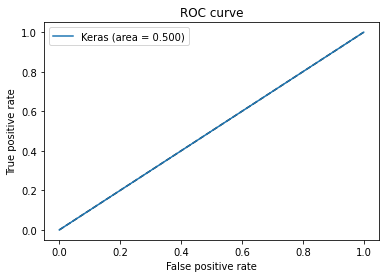

```python
from sklearn.metrics import roc_curve
import matplotlib.pyplot as plt

y_pred_keras = model.predict(X_test).ravel()
fpr_keras, tpr_keras, thresholds_keras = roc_curve(y_test, y_pred_keras)
from sklearn.metrics import auc
auc_keras = auc(fpr_keras, tpr_keras)


plt.figure(1)
plt.plot([0, 1], [0, 1], 'k--')
plt.plot(fpr_keras, tpr_keras, label='Keras (area = {:.3f})'.format(auc_keras))
plt.xlabel('False positive rate')
plt.ylabel('True positive rate')
plt.title('ROC curve')
plt.legend(loc='best')
plt.show()
```

## Submission File Prep

For each SK_ID_CURR in the test set, you must predict a probability for the TARGET variable. The file should contain a header and have the following format:

```
SK_ID_CURR,TARGET
100001,0.1
100005,0.9
100013,0.2
etc.
```

```python
test_class_scores = model.predict_proba(X_Kaggle_test)[:, 1]
```

[output not shown]

```python
test_class_scores[0:10]
```

[output not shown]

```python
# Submission dataframe
submit_df = datasets["application_test"][['SK_ID_CURR']]
submit_df['TARGET'] = test_class_scores

submit_df.head()
```

```python
submit_df.to_csv("submission.csv",index=False)
```

# Grid Search

```python
rungs=False
```

```python
from time import time
from sklearn.model_selection import cross_val_score, ShuffleSplit
cv30Splits = ShuffleSplit(n_splits=30, test_size=0.3, random_state=0)
```

```python
from sklearn.linear_model import LogisticRegression
from sklearn.neighbors import KNeighborsClassifier
from sklearn.naive_bayes import GaussianNB
from sklearn.svm import SVC
from sklearn.linear_model import SGDClassifier
from sklearn.ensemble import RandomForestClassifier
from sklearn.ensemble import AdaBoostClassifier
from scipy import stats
```

### XGBoost

```python
def ConductGridSearch(X_train, y_train, X_test, y_test, i=0, prefix='', n_jobs=-1,verbose=1):
    # Create a list of classifiers for our grid search experiment
    classifiers = [
        ('xgboost',XGBClassifier())
    ]

    params_grid = {
        'xgboost':{
            "learning_rate" : [0.05, 0.10, 0.15, 0.20, 0.25, 0.30 ],
            "max_depth"     : [ 3, 4, 5, 6, 8, 10, 12, 15],
            "min_child_weight" : [ 1, 3, 5, 7 ],
            "gamma"            : [ 0.0, 0.1, 0.2 , 0.3, 0.4 ],
            "colsample_bytree" : [ 0.3, 0.4, 0.5 , 0.7 ]
        }
     }

    for (name, classifier) in classifiers:
        i += 1
        # Print classifier and parameters
        print('****** START',prefix, name,'*****')
        parameters = params_grid[name]
        print("Parameters:")
        for p in sorted(parameters.keys()):
            print("\t"+str(p)+": "+ str(parameters[p]))

        # generate the pipeline
        full_pipeline_with_predictor = Pipeline([
        ("predictor", classifier)
        ])

        # Execute the grid search
        params = {}
        for p in parameters.keys():
            pipe_key = 'predictor__'+str(p)
            params[pipe_key] = parameters[p]
        grid_search = RandomizedSearchCV(full_pipeline_with_predictor, params, n_iter=30, scoring='accuracy', cv=5, verbose=20, n_jobs=-1)
        grid_search.fit(X_train, y_train)

        # Best estimator score
        best_train = pct(grid_search.best_score_)
        print("Best Train:", best_train)
        # Best estimator fitting time
        start = time()
        grid_search.best_estimator_.fit(X_train, y_train)
        train_time = round(time() - start, 4)
        print("Train Time:", train_time)

        # Best estimator prediction time
        start = time()
        best_test_accuracy = pct(grid_search.best_estimator_.score(X_test, y_test))
        test_time = round(time() - start, 4)
        print("Test Time:", test_time)


        best_train_scores = cross_val_score(grid_search.best_estimator_, X_train, y_train, scoring="accuracy", cv=cv30Splits)
        print("Best Train Scores:", best_train_scores)
        best_train_accuracy = pct(np.mean(best_train_scores))
        print("Best Train Accuracy:", best_train_accuracy)


        logit_scores= np.round(accuracy_score(y_test, grid_search.best_estimator_.predict(X_test)), 3)

        # Conduct t-test with baseline logit (control) and best estimator (experiment)

        # Collect the best parameters found by the grid search
        print("Best Parameters:")
        best_parameters = grid_search.best_estimator_.get_params()
        param_dump = []
        for param_name in sorted(params.keys()):
            param_dump.append((param_name, best_parameters[param_name]))
            print("\t"+str(param_name)+": " + str(best_parameters[param_name]))
        print("****** FINISH",prefix,name," *****")
        print("")

        # Record the results
        results.loc[i] = [prefix+name, best_train_accuracy, best_test_accuracy, train_time, test_time, json.dumps(param_dump)]
```

```python
# %%time
#print(time())
# This might take a while
if rungs:
    # multiprocessing requires the fork to happen in a __main__ protected
    # block

    # find the best parameters for both the feature extraction and the
    # classifier
    # n_jobs=-1 means that the computation will be dispatched on all the CPUs of the computer.
    #
    # By default, the GridSearchCV uses a 3-fold cross-validation. However, if it
    #            detects that a classifier is passed, rather than a regressor, it uses a stratified 3-fold.
    ConductGridSearch(X_train, y_train, X_test, y_test, 0, "Best Model:",  n_jobs=-1,verbose=1)
```

[output not shown]

[output not shown]

[output not shown]

[output cut: 14 more lines]

[output not shown]

### XGBoost Output

[output not shown]

### LightGBM

```python
def lgb_gridsearch_pipeline(X_train_data, X_test_data, y_train_data, y_test_data,
                       model, param_grid, cv=10, scoring_fit='neg_mean_squared_error',
                       do_probabilities = False):
    gs = GridSearchCV(
        estimator=model,
        param_grid=param_grid,
        cv=cv,
        n_jobs=-1,
        scoring=scoring_fit,
        verbose=20
    )
    fitted_model = gs.fit(X_train_data, y_train_data)

    if do_probabilities:
      pred = fitted_model.predict_proba(X_test_data)
    else:
      pred = fitted_model.predict(X_test_data)

    return fitted_model, pred
```

```python
if rungs:
  X_train.columns = ["".join (c if c.isalnum() else "_" for c in str(x)) for x in X_train.columns]
  X_test.columns = ["".join (c if c.isalnum() else "_" for c in str(x)) for x in X_test.columns]
  model = lgb.LGBMClassifier()
  param_grid = {
      'n_estimators': [1100, 1200, 1300, 1500],
      'max_depth': [10,15,20,25],
      'num_leaves': [200]
  }


  model, pred = gb_gridsearch_pipeline(x_train, x_test, y_train, y_test, model,
                                  param_grid, cv=3, scoring_fit='roc_auc')

  print(model.best_score_)
  print(model.best_params_)
```

### LightGBM Output

This LightGBM Grid Search created following output. This model over fit the model with the number of leaves. The leaves had to be reduced with manual testing.

```
Fitting 3 folds for each of 16 candidates, totalling 48 fits

[Parallel(n_jobs=-1)]: Using backend LokyBackend with 4 concurrent workers.
[Parallel(n_jobs=-1)]: Done   1 tasks      | elapsed: 16.2min
[Parallel(n_jobs=-1)]: Done   2 tasks      | elapsed: 16.3min
[Parallel(n_jobs=-1)]: Done   3 tasks      | elapsed: 16.5min
[Parallel(n_jobs=-1)]: Done   4 tasks      | elapsed: 17.6min
[Parallel(n_jobs=-1)]: Done   5 tasks      | elapsed: 31.9min
[Parallel(n_jobs=-1)]: Done   6 tasks      | elapsed: 32.0min
[Parallel(n_jobs=-1)]: Done   7 tasks      | elapsed: 32.9min
[Parallel(n_jobs=-1)]: Done   8 tasks      | elapsed: 34.5min
/opt/conda/lib/python3.6/site-packages/joblib/externals/loky/process_executor.py:706: UserWarning: A worker stopped while some jobs were given to the executor. This can be caused by a too short worker timeout or by a memory leak.
  "timeout or by a memory leak.", UserWarning
[Parallel(n_jobs=-1)]: Done   9 tasks      | elapsed: 50.9min
[Parallel(n_jobs=-1)]: Done  10 tasks      | elapsed: 52.1min
[Parallel(n_jobs=-1)]: Done  11 tasks      | elapsed: 53.3min
[Parallel(n_jobs=-1)]: Done  12 tasks      | elapsed: 55.9min
[Parallel(n_jobs=-1)]: Done  13 tasks      | elapsed: 67.3min
[Parallel(n_jobs=-1)]: Done  14 tasks      | elapsed: 67.9min
[Parallel(n_jobs=-1)]: Done  15 tasks      | elapsed: 69.4min
[Parallel(n_jobs=-1)]: Done  16 tasks      | elapsed: 72.4min
[Parallel(n_jobs=-1)]: Done  17 tasks      | elapsed: 85.0min
[Parallel(n_jobs=-1)]: Done  18 tasks      | elapsed: 85.5min
[Parallel(n_jobs=-1)]: Done  19 tasks      | elapsed: 88.2min
[Parallel(n_jobs=-1)]: Done  20 tasks      | elapsed: 90.4min
[Parallel(n_jobs=-1)]: Done  21 tasks      | elapsed: 104.3min
[Parallel(n_jobs=-1)]: Done  22 tasks      | elapsed: 108.2min
[Parallel(n_jobs=-1)]: Done  23 tasks      | elapsed: 109.9min
[Parallel(n_jobs=-1)]: Done  24 tasks      | elapsed: 111.0min
[Parallel(n_jobs=-1)]: Done  25 tasks      | elapsed: 120.5min
[Parallel(n_jobs=-1)]: Done  26 tasks      | elapsed: 124.2min
[Parallel(n_jobs=-1)]: Done  27 tasks      | elapsed: 125.6min
[Parallel(n_jobs=-1)]: Done  28 tasks      | elapsed: 127.4min
[Parallel(n_jobs=-1)]: Done  29 tasks      | elapsed: 138.6min
[Parallel(n_jobs=-1)]: Done  30 tasks      | elapsed: 142.1min
[Parallel(n_jobs=-1)]: Done  31 tasks      | elapsed: 144.6min
[Parallel(n_jobs=-1)]: Done  32 tasks      | elapsed: 145.7min
[Parallel(n_jobs=-1)]: Done  33 tasks      | elapsed: 158.1min
[Parallel(n_jobs=-1)]: Done  34 tasks      | elapsed: 164.9min
[Parallel(n_jobs=-1)]: Done  35 tasks      | elapsed: 166.7min
[Parallel(n_jobs=-1)]: Done  36 tasks      | elapsed: 167.0min
[Parallel(n_jobs=-1)]: Done  37 tasks      | elapsed: 174.4min
[Parallel(n_jobs=-1)]: Done  38 tasks      | elapsed: 181.2min
[Parallel(n_jobs=-1)]: Done  39 tasks      | elapsed: 181.8min
[Parallel(n_jobs=-1)]: Done  40 tasks      | elapsed: 183.4min
[Parallel(n_jobs=-1)]: Done  41 tasks      | elapsed: 191.8min
[Parallel(n_jobs=-1)]: Done  44 out of  48 | elapsed: 202.0min remaining: 18.4min
[Parallel(n_jobs=-1)]: Done  48 out of  48 | elapsed: 221.5min finished

0.7451383824520795
{'max_depth': 25, 'n_estimators': 1300, 'num_leaves': 200}
```

# Kaggle submission via the command line API

```python
! kaggle competitions submit -c home-credit-default-risk -f submission.csv -m "baseline submission"
```

## report submission

Click on this [link](https://www.kaggle.com/c/home-credit-default-risk/submissions?sortBy=date&group=all&page=1)

[figure not shown]

# Write-up

For this phase of the project, you will need to submit a write-up summarizing the work you did. The write-up form is available on Canvas (Modules-> Module 12.1 - Course Project - Home Credit Default Risk (HCDR)-> FP Phase 2 (HCDR) : write-up form ). It has the following sections:

## Abstract

Home Credit is a non-banking financial institution that uses sources like transactional data and telecom data, to get insights into the applicant’s finances and determine their repayment capabilities and accordingly help them to obtain loans. These insights are to answer the biggest question the company has, will the applicant be able to repay the loan?

We were required to understand the dataset, extract relevant features, perform experiments using various machine learning algorithms and determine the best performing parameters.

We did EDA, visualize the data for better presentation, find the correlation between the various data elements, create new features from existing data, rollup and aggregate wherever necessary. All this was done using pipelines so that our solutions remain clean and reproducible.

We used a subset of available features, extracted additional features and ran through the models comprising Logistic Regression, XGABoost and LightGBM. We got the best Kaggle score of .767.

## Introduction

Home Credit share the data in 7 different files:

- **application_train/application_test:** the main training and testing data with information about each loan application at Home Credit. Every loan has its own row and is identified by the feature SK_ID_CURR. The training application data comes with the TARGET indicating **0: the loan was repaid** or **1: the loan was not repaid**. The target variable defines if the client had payment difficulties meaning he/she had late payment more than X days on at least one of the first Y installments of the loan. Such case is marked as 1 while other all other cases as 0.
- **bureau:** data concerning client's previous credits from other financial institutions. Each previous credit has its own row in bureau, but one loan in the application data can have multiple previous credits.
- **bureau_balance:** monthly data about the previous credits in bureau. Each row is one month of a previous credit, and a single previous credit can have multiple rows, one for each month of the credit length.
- **previous_application:** previous applications for loans at Home Credit of clients who have loans in the application data. Each current loan in the application data can have multiple previous loans. Each previous application has one row and is identified by the feature SK_ID_PREV.
- **POS_CASH_BALANCE:** monthly data about previous point of sale or cash loans clients have had with Home Credit. Each row is one month of a previous point of sale or cash loan, and a single previous loan can have many rows.
- **credit_card_balance:** monthly data about previous credit cards clients have had with Home Credit. Each row is one month of a credit card balance, and a single credit card can have many rows.
- **installments_payment:** payment history for previous loans at Home Credit. There is one row for every made payment and one row for every missed payment.

## Feature Engineering and transformers

We created custom transformers for each of the datasets. There are Feature Aggregators, One Hot Encoders and Column Encoders depending on the need of the data. Once we had merged the data we had 200+ features. With experiments we were able to determine what features didnt help and we dropped those features. Below are the snapshots of some new features extracted from the Application data set and the transformer for the Bureau data:

[figure not shown]

## Pipelines

There are multiple pipelines created. There are individual pipelines for each data set that Encode and Aggregate the specific dataset. Thereafter we have the Data Merge Pipeline that transforms the application (test and train) datasets and merges them with each of the auxillary datasets resulting into 2 final datasets the X_train_full and X_Kaggle_test. The merge pipeline is invoked for both Test ad Train sets to make sure that same processing steps are applied on both the data sets.

Thereafter there is the Data Prep pipeline that users this data and runs the Standard Scaler process on it and imputer to fill the missing data. There are individual pipelines for each of the baseline models i.e. Logistic Regression, XGBoost and LightGBM that call the Data Prep Pipeline to get the train data.

In the pipeline code below one can see how one pipeline calls the other therefore making the code reliable and rerunnable:

- **Data Merge Pipeline**

```
data_merge_pipeline = Pipeline([
    ('applData',apl_pipeline),
    ('mergeData',mergeData(dflist)),
    ])
```

- **Full Pipeline for LGB**

```
full_pipeline_LGB = Pipeline([
        ("preparation", data_prep_pipeline),
        ("lgb",LGBMClassifier(n_estimators=1300,n_jobs = -1, max_depth=25, num_leaves=5))
    ])
```

## Experimental results

Multiple experiments were performed. The team worked in parallel with one of the members working on feature engineering and passing the data depending on how the baseline tests go, to the team members doing the grid search narrowing down the best parameters. The results were logged and preserved. Below is the sample log:

[figure not shown]

A csv file was generated and submitted to Kaggle and the reults recorded. Here is a sample of the submission:

[figure not shown]

## Discussion

The most time consuming task has been the feature engineering and the feature selection. Once we were able to build and wrap everything into pipelines the code became much simpler to maintain.

[figure not shown]

## Conclusion

We found that the following features have the most affect on determining whethere the customer should be granted the loan or not:

1. EXT_SOURCE_3
2. EXT_SOURCE_2
3. EXT_SOURCE_1
4. DAYS_BIRTH
5. REGION_RATING_CLIENT_W_CITY

## Kaggle Submission

[figure not shown]

# References

Some of the material in this notebook has been adopted from [here](https://www.kaggle.com/willkoehrsen/start-here-a-gentle-introduction/notebook) and the code to reduce the memory footprint has been taken from [here](https://www.mikulskibartosz.name/how-to-reduce-memory-usage-in-pandas/)